# Task11_Jumps_In_Sensitivity_Analysis

Hongshan Li

This indicates that our approximation of Keq does not apply when ksynM3 is large (or when target concentration is large). By definition
$$K_{ssd, mem} = \frac{D_3\cdot M_3}{DM_3}$$
so it is reasonable that as ksynM3 gets big, $K_{ssd, mem}$ gets big. Then, we will not be able assume (2.2.20 of the writeup)
$$\frac{T_3}{T_{3tot}} = \frac{K_{eq}}{K_{eq} + D_3} \sim
\frac{K_{eq}}{D_3}$$

Therefore, in order for the above approximation to be true, we will have to increase the dose for large ksynM3, so that $Keq << D_3$.

I will run a sensitivity analysis on ksynM3 with the same range of value as in Task05, but I will significantly increase the dose. Then, we should be able to  
see better agreement between theory and simulation

```r
suppressMessages(source("ams_initialize_script.R"))
suppressMessages(source("ams_initialize_script.R"))
model = ivsc_4cmtct_shedct(target=TRUE)

# test on Pemb, and run senstivity analysis on ksynM3
drug = "Pembrolizumab"
drug.path = paste0("../data/ModelF_", drug, "_Params.xlsx")
parameter = "ksynM3"

# Set global variables
tmax = 26*7
tau = 21
compartment = 2

# Load model parameters for pemb
param.as.double = read.param.file(drug.path)
df_param = as.data.frame(t(param.as.double))

# grep ksynM3
ksynM3.init = df_param["ksynM3"]

# set the range for ksynM3
ksynM3.range = data.frame(lapply(ksynM3.init, function(x) lseq(x*0.01, x*100, 7)))
```

With low dose

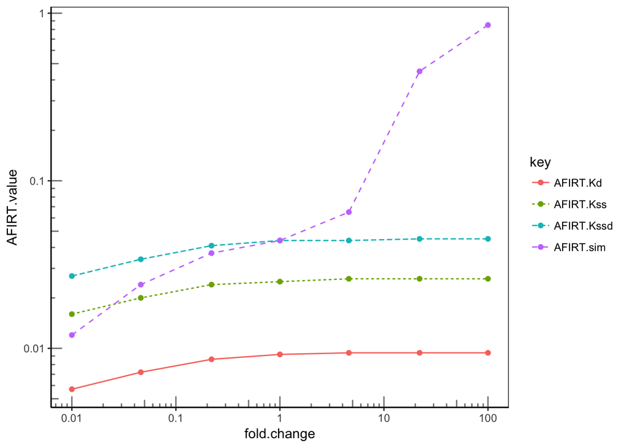

```r
dose.nmol = scale.mpk2nmol
# run the sensitivity analysis on the above range
AFIRT = compare.thy.sim(model=model,
                    param.as.double=param.as.double,
                    dose.nmol = dose.nmol,
                    tmax = tmax,
                    tau = tau,
                    compartment = compartment,
                    param.to.change = 'ksynM3',
                    param.to.change.range = ksynM3.range[[1]],
                    soluble = FALSE)

# get the relevant data from the above frame
relevant = AFIRT[c("fold.change", "AFIRT.Kssd", "AFIRT.Kss","AFIRT.Kd", "AFIRT.sim", "param")]

relevant = relevant %>%
  gather(key, AFIRT.value, -param, -fold.change) %>%
  filter(!is.na(AFIRT.value))

g = ggplot(relevant, aes(fold.change, AFIRT.value, color=key, linetype=key)) +
  scale.x.log10() +
  scale.y.log10() +
  geom_line() +
  geom_point()

print(g)
```

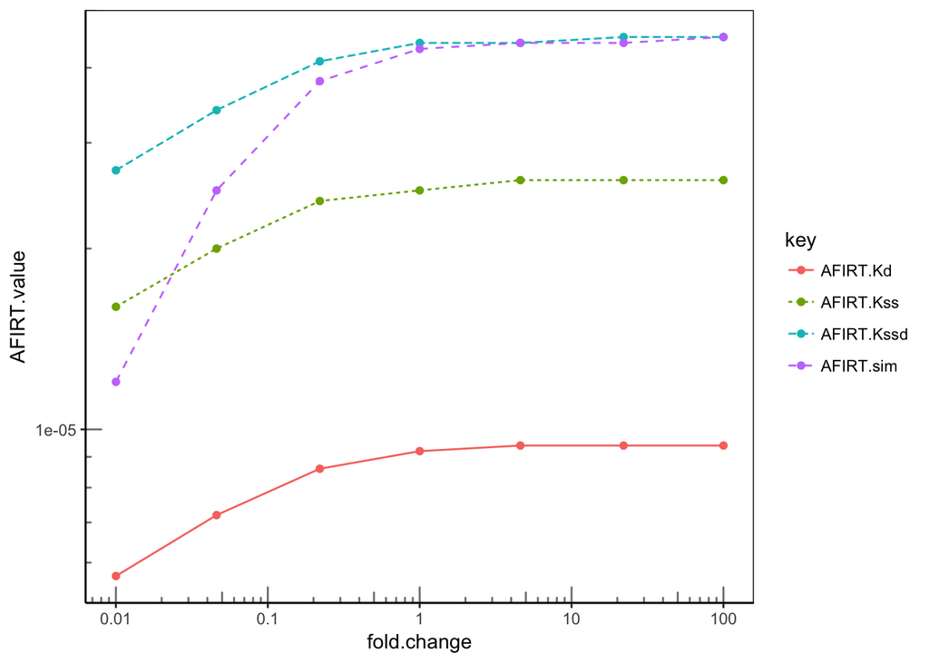

```r
dose.nmol = 1000*scale.mpk2nmol
# run the sensitivity analysis on the above range
AFIRT = compare.thy.sim(model=model,
                    param.as.double=param.as.double,
                    dose.nmol = dose.nmol,
                    tmax = tmax,
                    tau = tau,
                    compartment = compartment,
                    param.to.change = 'ksynM3',
                    param.to.change.range = ksynM3.range[[1]],
                    soluble = FALSE)

# get the relevant data from the above frame
relevant = AFIRT[c("fold.change", "AFIRT.Kssd", "AFIRT.Kss","AFIRT.Kd", "AFIRT.sim", "param")]

relevant = relevant %>%
  gather(key, AFIRT.value, -param, -fold.change) %>%
  filter(!is.na(AFIRT.value))

g = ggplot(relevant, aes(fold.change, AFIRT.value, color=key, linetype=key)) +
  scale.x.log10() +
  scale.y.log10() +
  geom_line() +
  geom_point()

print(g)
```